# Lab 01.2 - FPCC 2

Tiaraju Smaneoto

# Questões a serem respondidas:

#### a. Em que tipo de despesas os parlamentares gastam mais recursos de sua cota?

#### b. Que tipos de despesa tem valores que mais variam quando comparamos os deputados?

# Dados

Os dados que serão analisados serão restringidos aos parlamentares da unidade federativa da Bahia (BBMP) :)

#### a. Em que tipo de despesas os parlamentares gastam mais recursos de sua cota?

Primeiramente, vamos observar os tipos de gasto mais frequentes entre os deputados da Bahia. Para isso, analisaremos a variável txtDescricao, que especifica a descrição do gasto. Agruparemos por tal variável para contar o número de ocorrências.

Uma ressalva importante é que tivemos que fazer merge das variáveis Emissão de Bilhete Aéreo e Passagens Aéreas, uma vez que, no contexto da análise, os dois se referem ao mesmo tipo gasto.

Outro ponto importante considerado foi a presença de valores negativos para a variável vlrLiquido. Todavia, foi averiguado, segundo a descrição das variáveis, que o valor negativo representa o valor de um bilhete aéreo que foi emitido em substituição de outro não usado, o que não causa problema na nossa análise.

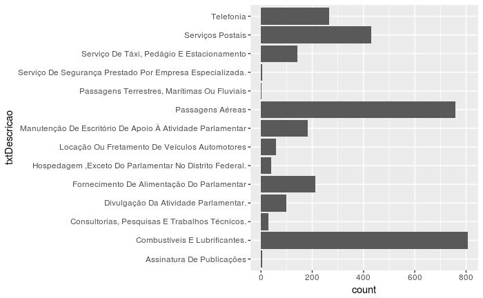

```r
dados = read.csv("dados//AnoAtual.csv")  %>% filter(sgUF=="BA")
dados$txtDescricao[dados$txtDescricao == "Emissão Bilhete Aéreo"] <- "PASSAGENS AÉREAS"
dados$numSubCota[dados$numSubCota == 9] <- 999
dados = dados %>% mutate(txtDescricao=str_to_title(txtDescricao))
dados %>%  ggplot() + geom_bar(mapping=aes(x=txtDescricao)) + coord_flip()
```

Podemos observar que, em número de observações, Combustíveis e lubrificantes é o tipo de despesa que mais aparece, seguido por Emissão de bilhete aéreo.

Agora, respondendo à primeira questão, vamos observar onde se concentram os maiores gastos. Para tal, analisaremos a variável vlrLiquido agrupada por tipo de descrição.

O resultado é mostrado no gráfico abaixo:

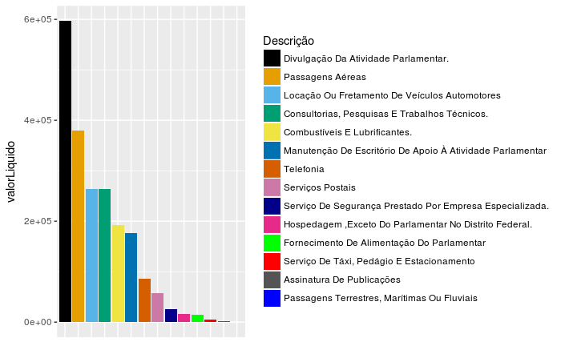

```r
gasto_por_desc <- aggregate(dados$vlrLiquido ~ dados$txtDescricao, dados, sum)
gasto_por_desc <- gasto_por_desc %>% select(descricao=`dados$txtDescricao`, valorLiquido=`dados$vlrLiquido`)
#paleta de cores
cbbPalette <- c("#000000", "#E69F00", "#56B4E9", "#009E73", "#F0E442", "#0072B2", "#D55E00", "#CC79A7"
                , "#00008B", "#E7298A", "#00FF00", "#FF0000", "#545454", "#0000FF", "#E6AB02")

gasto_por_desc %>% ggplot(aes(x=reorder(descricao,-valorLiquido), y=valorLiquido, fill=reorder(descricao,-valorLiquido) )) +
  geom_bar(stat="identity") + theme(axis.title.x=element_blank(), axis.text.x=element_blank(),axis.ticks.x=element_blank())+ scale_fill_manual(values=cbbPalette, name="Descrição")
```

Podemos observar que os três tipos de despesas onde os parlamentares mais gastam seus recursos são:

- Divulgação de atividade parlamentar
- Passagens Aéreas
- Locação ou fretamento de Veículos

#### b. Que tipos de despesa tem valores que mais variam quando comparamos os deputados?

Agora, respondendo à segunda questão:

Para responder a segunda questão, analisaremos as variáveis txNomeParlamentar, txDescricao e vlrLiquido que representam: o Nome do parlamentar, a descrição do gasto da cota, e o valor gasto, respectivamente. Para tal, agruparemos as variáveis de modo a calcular o desvio padrão das categorias de gasto(txDecricao) entre os deputados.

O maior desvio padrão encontrado nos mostrará a categoria que mais varia entre os deputados.

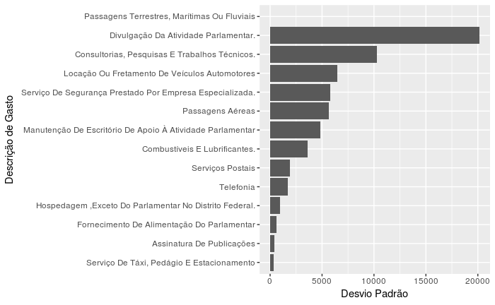

```r
  group_por_desc = dados %>%
  select(txNomeParlamentar, txtDescricao, vlrLiquido) %>%
  group_by(txNomeParlamentar, txtDescricao) %>%
  summarise(total_gasto = sum(vlrLiquido))
  std_dep_ba = group_por_desc %>%
  group_by(txtDescricao) %>%
  summarise(std = sd(total_gasto))
ggplot(std_dep_ba, aes(x=reorder(txtDescricao, std), y=std)) +
  geom_bar(stat = "identity") +
  labs(x='Descrição de Gasto', y='Desvio Padrão')+
  coord_flip()
```

Podemos ver no gráfico acima que, as três categorias em que o valor Liquido mais varia, entre os parlamentares, são: * Divulgação Da Atividade Parlamentar * Consultorias, Pesquisa e Trabalhos Técnicos * Locação Ou fretamento de Veículos Automotores